# Calibrated Bayesian One-Sample and Paired t-Tests for Continuous Endpoints in Clinical Trials

Riko Kelter Institute of Medical Statistics and Computational Biology Faculty of Medicine, University of Cologne Cologne, Germany

26 October 2026

```r
library(bfbin2arm)

# Use default controls for reproducible vignette results.
# For interactive exploratory work, users may supply a faster control list.
control_fast <- list(
  n_search = "two_stage",
  n_step_stage1 = 10L,
  rel_tol_m1 = 1e-6,
  subdivisions_m1 = 100L,
  grid_n = 121L,
  t_max = 6,
  t_max_cap = 16,
  root_tol = 1e-8,
  verify = FALSE
)

control_full_fast <- list(
  n_search = "full_fast",
  rel_tol_m1 = 1e-6,
  subdivisions_m1 = 100L,
  grid_n = 121L,
  t_max = 6,
  root_tol = 1e-8,
  verify = FALSE,
  progress = TRUE
)

vignette_control <- list(
  n_search = "full",
  rel_tol_m1 = 1e-9,
  subdivisions_m1 = 800L,
  grid_n = 801L,
  t_max = 12,
  t_max_cap = 40,
  root_tol = 1e-12,
  verify = TRUE,
  verify_rel_tol_m1 = 1e-10,
  verify_subdivisions_m1 = 1200L,
  verify_grid_n = 1201L,
  verify_t_max = 15,
  verify_root_tol = 1e-12,
  progress = TRUE
)
```

## 1 Overview

This vignette illustrates deterministic calibration of Bayesian one-sample and paired $t$-test designs for continuous clinical endpoints. The examples are prospective, trial-inspired design illustrations; they do not reproduce the original trials’ analyses or numerical results.

The function `calibrate_bf_ttest()` searches the requested range of sample sizes and returns the smallest feasible integer sample size. It evaluates evidence using the Bayes factor $BF_{01}$, where smaller values favour $H_1$ and larger values favour $H_0$.

The package supports three hypotheses:

$$H_0:\delta=0 \quad \text{versus} \quad H_1:\delta\ne0,$$

$$H_0:\delta=0 \quad \text{versus} \quad H_1:\delta>0,$$

and

$$H_0:\delta\le0 \quad \text{versus} \quad H_1:\delta>0.$$

Here, $\delta$ is the standardized mean effect. For directional examples, the endpoint is coded so that positive values represent clinical benefit.

## 2 Example 1: Two-sided point-null design

This example is inspired by a phase-2 COPD study involving ivacaftor, compare Vijaykumar et al. (2025). We consider a hypothetical single-arm proof-of-concept study whose endpoint is change in prebronchodilator forced expiratory volume in 1 second (FEV1) percent predicted at Day 84.

Suppose that a 5-percentage-point improvement is clinically relevant and that the planning standard deviation is 12.5 percentage points. The corresponding standardized effect is

$$\delta_A = \frac{5}{12.5} = 0.40.$$

We use the two-sided point-null hypothesis

$$H_0:\delta=0
\quad\text{versus}\quad
H_1:\delta\ne0.$$

The analysis prior under $H_1$ is $N(0, 0.5^2)$. This prior defines the Bayes factor used at analysis; it is not the same as the design prior used to evaluate operating characteristics.

The design prior under $H_0$ is a point mass at $\delta=0$. Under $H_1$, we use a truncated normal design prior centred at the anticipated beneficial effect, $TN(0.40, 0.20^2; [0,\infty))$. This represents uncertainty about the size of a beneficial effect while excluding harmful effects from the beneficial-effect planning scenario.

```r
pulmonary_normal_dp <- calibrate_bf_ttest(
  design = "one.sample",
  hypothesis = "two.sided.pointnull",

  # Search range for the number of evaluable participants
  n_min = 20,
  n_max = 200,

  # Evidence thresholds:
  # BF01 <= 0.10 is compelling evidence for H1;
  # BF01 >= 3 is compelling evidence for H0.
  k1 = 1 / 10,
  k0 = 3,

  # Analysis prior under H1: N(0, 0.5^2)
  analysis_prior_sd = 0.5,

  # Error probability for incorrectly obtaining evidence for H1
  # when the true standardized effect is exactly zero.
  freq_t1e = 0.05,
  bayes_t1e = 0.05,

  # Frequentist power at the clinically relevant point alternative.
  freq_power = list(
    main = list(effect = 0.40, target = 0.80)
  ),

  # Average probability of evidence for H1 under the H1 design prior.
  bayes_power = 0.80,

  # Probability of compelling evidence for H0 under the H0 design prior.
  # Including this argument also computes and stores the H0 evidence region.
  pce_h0 = 0.60,

  # Design priors used only for operating-characteristic calculations.
  design_prior_h0 = list(type = "point", effect = 0),
  design_prior_h1 = list(
    type = "truncnormal",
    mean = 0.40,
    sd = 0.20,
    lower = 0,
    upper = Inf
  ),

  control = control_full_fast
)

print(pulmonary_normal_dp)
```

```
Calibrated Bayesian t-test design
---------------------------------
Design: one.sample
Hypothesis: two.sided.pointnull
n*: 161 (df = 160 )
Thresholds: k1 = 0.1 , k0 = 3
Analysis prior under H0:
Point prior: delta = 0
Analysis prior under H1:
Prior: N(0, 0.5^2)
  family:   normal
  location: 0
  scale:    0.5
  support:  [-Inf, Inf]
Evidence for H1 region(s) on t-scale:
        lower     upper
[1,]     -Inf -2.951809
[2,] 2.951809       Inf
Evidence for H0 region(s) on t-scale:
         lower    upper
[1,] -1.248312 1.248312

Constraints:
      constraint        type
        freq_t1e frequentist
       bayes_t1e    Bayesian
     bayes_power    Bayesian
          pce_h0    Bayesian
 freq_power_main frequentist
                estimand    estimate target
   P_delta=0(BF01 <= k1) 0.003634714   0.05
 P_design,H0(BF01 <= k1) 0.003634714   0.05
 P_design,H1(BF01 <= k1) 0.800167910   0.80
 P_design,H0(BF01 >= k0) 0.786259448   0.60
 P_delta=0.4(BF01 <= k1) 0.982124193   0.80
 direction      slack satisfied
        <= 0.04636529      TRUE
        <= 0.04636529      TRUE
        >= 0.00016791      TRUE
        >= 0.18625945      TRUE
        >= 0.18212419      TRUE
```

The printed result reports the selected sample size $n^*$, the decision regions on the observed-$t$ scale, and the attained values of every active constraint. For this configuration, the calibrated result is $n^*=161$ ($df=160$); the evidence-for-$H_1$ region is approximately $t\le -2.95$ or $t\ge 2.95$.

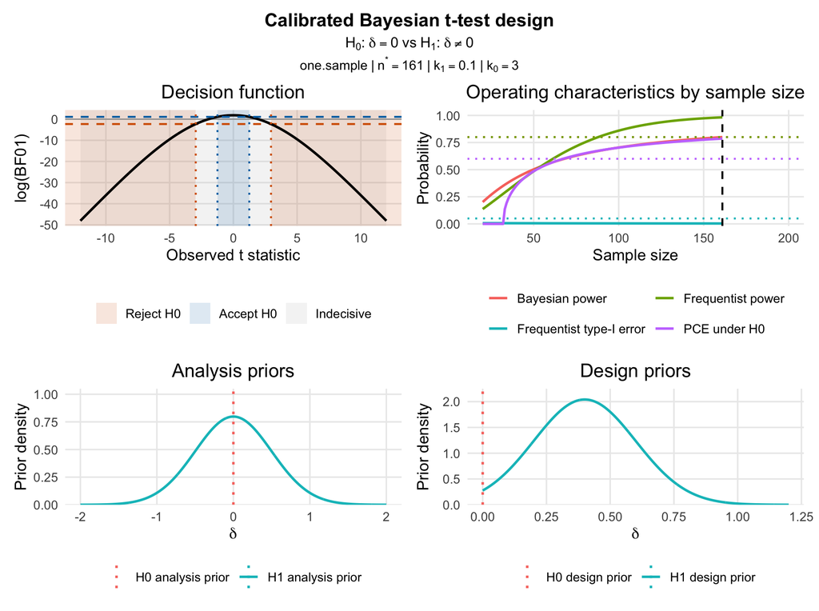

Figure 1: Output of the plot function for a one-sample Bayesian two-sided point-null t-test design based on full calibration. Both Bayesian and frequentist power and type-I-error are calibrated jointly.

```r
plot(pulmonary_normal_dp)
```

The frequentist type-I error is the probability, at $\delta=0$, of obtaining $BF_{01}\le 0.10$, that is, compelling evidence for $H_1$ when the point null is true. The Bayesian type-I error averages that same probability over the $H_0$ design prior. Because the $H_0$ design prior here is a point mass at zero, these two values coincide.

The operating-characteristic plot displays their shared curve as “Frequentist type-I error” rather than drawing two coincident curves and repeating the legend entry.

The frequentist power constraint evaluates $P_{\delta=0.40}(BF_{01}\le 0.10)$. In contrast, `bayes_power` averages $P_{\delta}(BF_{01}\le 0.10)$ over the continuous $H_1$ design prior. Thus, the two power requirements answer different planning questions.

The `pce_h0` constraint evaluates the probability of obtaining compelling evidence for the null, $BF_{01}\ge3$, under the $H_0$ design prior. This implies that a minimum probability of obtaining a Bayes factor in favour of $H_0$ of at least size $3$ or larger is fixed, when $H_0$ is true. In this example, it also causes the function to calculate the central evidence-for-$H_0$ region. The interval is shown by the printed object and by the blue-shaded region in the decision-function plot in the top left.

The decision panel displays $\log(BF_{01})$. The orange dashed line denotes $\log(k_1)$, so values below it support $H_1$; the blue dashed line denotes $\log(k_0)$, so values above it support $H_0$. The shaded regions represent the stored decision regions: orange for evidence for $H_1$, blue for evidence for $H_0$, and grey for inconclusive results. The sample-size panel shows the operating characteristics throughout the search and marks the selected $n^*$.

### 2.1 A brief comparison of calibration modes

The first example above calibrated both frequentist and Bayesian operating characteristics such as power and type-I-error jointly. Also, the probability of compelling evidence for $H_0$ was calibrated. Next, we compare the different calibration modes available. We can pick whatever combination we like as the calibration target, but the most prominent choices might include:

- Frequentist calibration
- Bayesian calibration
- Hybrid calibration
- Full calibration

We use identical arguments including our design and analysis priors for all calibrations below, as specified in the following code chunk:

```r
library(bfbin2arm)

vignette_control <- resolve_control_bf_ttest()

common_args <- list(
  design = "one.sample",
  hypothesis = "two.sided.pointnull",

  n_min = 20,
  n_max = 200,

  # BF01 <= 0.10: evidence for H1
  # BF01 >= 3: available as a reference threshold, but no PCE constraint here
  k1 = 1 / 10,
  k0 = 3,

  # Analysis prior under H1: N(0, 0.5^2)
  analysis_prior_sd = 0.5,

  # H0 design prior: exact null
  design_prior_h0 = list(type = "point", effect = 0),

  # H1 design prior: uncertain beneficial effect
  design_prior_h1 = list(
    type = "truncnormal",
    mean = 0.40,
    sd = 0.20,
    lower = 0,
    upper = Inf
  ),

  control = control_full_fast
)
```

#### 2.1.1 Frequentist calibration

This design requires frequentist type-I error at most 0.05 and frequentist power at $\delta=0.40$ of at least 0.80.

```r
pulmonary_freq <- do.call(
  calibrate_bf_ttest,
  c(
    common_args,
    list(
      freq_t1e = 0.05,
      freq_power = list(
        main = list(effect = 0.40, target = 0.80)
      )
    )
  )
)

print(pulmonary_freq)
```

```
Calibrated Bayesian t-test design
---------------------------------
Design: one.sample
Hypothesis: two.sided.pointnull
n*: 88 (df = 87 )
Thresholds: k1 = 0.1 , k0 = 3
Analysis prior under H0:
Point prior: delta = 0
Analysis prior under H1:
Prior: N(0, 0.5^2)
  family:   normal
  location: 0
  scale:    0.5
  support:  [-Inf, Inf]
Evidence for H1 region(s) on t-scale:
        lower     upper
[1,]     -Inf -2.897943
[2,] 2.897943       Inf
Evidence for H0 region(s) on t-scale:
none

Constraints:
      constraint        type                estimand
        freq_t1e frequentist   P_delta=0(BF01 <= k1)
 freq_power_main frequentist P_delta=0.4(BF01 <= k1)
    estimate target direction        slack satisfied
 0.004751998   0.05        <= 0.0452480024      TRUE
 0.800302685   0.80        >= 0.0003026846      TRUE
```

#### 2.1.2 Bayesian calibration

This design requires Bayesian type-I error at most 0.05 and Bayesian power of at least 0.80 under the specified $H_1$ design prior.

```r
pulmonary_bayes <- do.call(
  calibrate_bf_ttest,
  c(
    common_args,
    list(
      bayes_t1e = 0.05,
      bayes_power = 0.80
    )
  )
)

print(pulmonary_bayes)
```

```
Calibrated Bayesian t-test design
---------------------------------
Design: one.sample
Hypothesis: two.sided.pointnull
n*: 161 (df = 160 )
Thresholds: k1 = 0.1 , k0 = 3
Analysis prior under H0:
Point prior: delta = 0
Analysis prior under H1:
Prior: N(0, 0.5^2)
  family:   normal
  location: 0
  scale:    0.5
  support:  [-Inf, Inf]
Evidence for H1 region(s) on t-scale:
        lower     upper
[1,]     -Inf -2.951809
[2,] 2.951809       Inf
Evidence for H0 region(s) on t-scale:
none

Constraints:
  constraint     type                estimand    estimate
   bayes_t1e Bayesian P_design,H0(BF01 <= k1) 0.003634714
 bayes_power Bayesian P_design,H1(BF01 <= k1) 0.800167910
 target direction      slack satisfied
   0.05        <= 0.04636529      TRUE
   0.80        >= 0.00016791      TRUE
```

#### 2.1.3 Hybrid calibration

This hybrid design controls type-I error at the exact null and requires average Bayesian power under the H1 design prior.

```r
pulmonary_bayes_power_freq_t1e <- do.call(
  calibrate_bf_ttest,
  c(
    common_args,
    list(
      freq_t1e = 0.05,
      bayes_power = 0.80
    )
  )
)

print(pulmonary_bayes_power_freq_t1e)
```

```
Calibrated Bayesian t-test design
---------------------------------
Design: one.sample
Hypothesis: two.sided.pointnull
n*: 161 (df = 160 )
Thresholds: k1 = 0.1 , k0 = 3
Analysis prior under H0:
Point prior: delta = 0
Analysis prior under H1:
Prior: N(0, 0.5^2)
  family:   normal
  location: 0
  scale:    0.5
  support:  [-Inf, Inf]
Evidence for H1 region(s) on t-scale:
        lower     upper
[1,]     -Inf -2.951809
[2,] 2.951809       Inf
Evidence for H0 region(s) on t-scale:
none

Constraints:
  constraint        type                estimand    estimate
    freq_t1e frequentist   P_delta=0(BF01 <= k1) 0.003634714
 bayes_power    Bayesian P_design,H1(BF01 <= k1) 0.800167910
 target direction      slack satisfied
   0.05        <= 0.04636529      TRUE
   0.80        >= 0.00016791      TRUE
```

#### 2.1.4 Full calibration

This activates all four error/power constraints, but deliberately does not require a minimum probability of compelling evidence for $H_0$.

```r
pulmonary_full_no_pce <- do.call(
  calibrate_bf_ttest,
  c(
    common_args,
    list(
      freq_t1e = 0.05,
      bayes_t1e = 0.05,
      freq_power = list(
        main = list(effect = 0.40, target = 0.80)
      ),
      bayes_power = 0.80

      # Deliberately omit:
      # pce_h0 = ...
    )
  )
)

print(pulmonary_full_no_pce)
```

```
Calibrated Bayesian t-test design
---------------------------------
Design: one.sample
Hypothesis: two.sided.pointnull
n*: 161 (df = 160 )
Thresholds: k1 = 0.1 , k0 = 3
Analysis prior under H0:
Point prior: delta = 0
Analysis prior under H1:
Prior: N(0, 0.5^2)
  family:   normal
  location: 0
  scale:    0.5
  support:  [-Inf, Inf]
Evidence for H1 region(s) on t-scale:
        lower     upper
[1,]     -Inf -2.951809
[2,] 2.951809       Inf
Evidence for H0 region(s) on t-scale:
none

Constraints:
      constraint        type                estimand
        freq_t1e frequentist   P_delta=0(BF01 <= k1)
       bayes_t1e    Bayesian P_design,H0(BF01 <= k1)
     bayes_power    Bayesian P_design,H1(BF01 <= k1)
 freq_power_main frequentist P_delta=0.4(BF01 <= k1)
    estimate target direction      slack satisfied
 0.003634714   0.05        <= 0.04636529      TRUE
 0.003634714   0.05        <= 0.04636529      TRUE
 0.800167910   0.80        >= 0.00016791      TRUE
 0.982124193   0.80        >= 0.18212419      TRUE
```

The frequentist-only calibration selects $n^*=88$, because it requires 80% probability of evidence for $H_1$ only at the single planning effect $\delta=0.40$. The Bayesian-power requirement averages this probability over the H1 design prior, which includes smaller positive effects; this produces the larger sample size $n^*=161$.

The Bayesian-only, Bayesian-power-plus-frequentist-type-I-error, and full no-PCE calibrations select the same sample size in this illustration. This occurs because the $H_0$ design prior is a point mass at $\delta=0$, making the Bayesian and frequentist type-I error quantities numerically identical, and because the attained frequentist power at $\delta=0.40$ already exceeds its 0.80 target at $n=161$. No calibration includes a PCE requirement. Hence, none requires a minimum probability of compelling evidence for $H_0$.

## 3 Example 2: Directional point-null design

Consider the same pulmonary endpoint when the confirmatory scientific question is restricted to benefit. The directional point-null test compares $H_0:\delta=0$ with $H_1:\delta>0$.

The analysis prior under $H_1$ is a normal distribution truncated to positive standardized effects, $N(0, 0.5^2)\mathbb{I}(\delta>0)$. Consequently, an adverse observed change does not provide evidence for the beneficial alternative. The design prior under $H_1$ represents uncertainty about the anticipated beneficial effect.

```r
directional_common_args <- list(
  design = "one.sample",
  hypothesis = "greater.pointnull",

  # Search range for the number of evaluable participants.
  n_min = 20,
  n_max = 200,

  # BF01 <= 0.10: compelling evidence for benefit (H1).
  # BF01 >= 3: available as a decision threshold, but no PCE constraint is
  # imposed in the calibrations below.
  k1 = 1 / 10,
  k0 = 3,

  # Directional H1 analysis prior:
  # N(0, 0.5^2), truncated to delta > 0.
  analysis_prior_sd = 0.5,

  # H0 design prior: exact null effect.
  design_prior_h0 = list(type = "point", effect = 0),

  # H1 design prior: uncertain beneficial effect.
  design_prior_h1 = list(
    type = "truncnormal",
    mean = 0.40,
    sd = 0.20,
    lower = 0,
    upper = Inf
  ),

  control = control_full_fast
)
```

### 3.1 Frequentist calibration

This design controls frequentist type-I error at the exact null and requires frequentist power of at least 80% at $\delta=0.40$.

```r
pulmonary_directional_freq <- do.call(
  calibrate_bf_ttest,
  c(
    directional_common_args,
    list(
      freq_t1e = 0.05,
      freq_power = list(
        main = list(effect = 0.40, target = 0.80)
      )
    )
  )
)

print(pulmonary_directional_freq)
```

```
Calibrated Bayesian t-test design
---------------------------------
Design: one.sample
Hypothesis: greater.pointnull
n*: 75 (df = 74 )
Thresholds: k1 = 0.1 , k0 = 3
Analysis prior under H0:
Point prior: delta = 0
Analysis prior under H1:
Prior: TN(0, 0.5^2; [0, Inf))
  family:   normal
  location: 0
  scale:    0.5
  support:  [0, Inf]
Evidence for H1 region(s) on t-scale:
        lower upper
[1,] 2.601071   Inf
Evidence for H0 region(s) on t-scale:
none

Constraints:
      constraint        type                estimand
        freq_t1e frequentist   P_delta=0(BF01 <= k1)
 freq_power_main frequentist P_delta=0.4(BF01 <= k1)
    estimate target direction       slack satisfied
 0.005608335   0.05        <= 0.044391665      TRUE
 0.803068443   0.80        >= 0.003068443      TRUE
```

We see that the number of patients decreases compared to the two-sided test. We can plot the design:

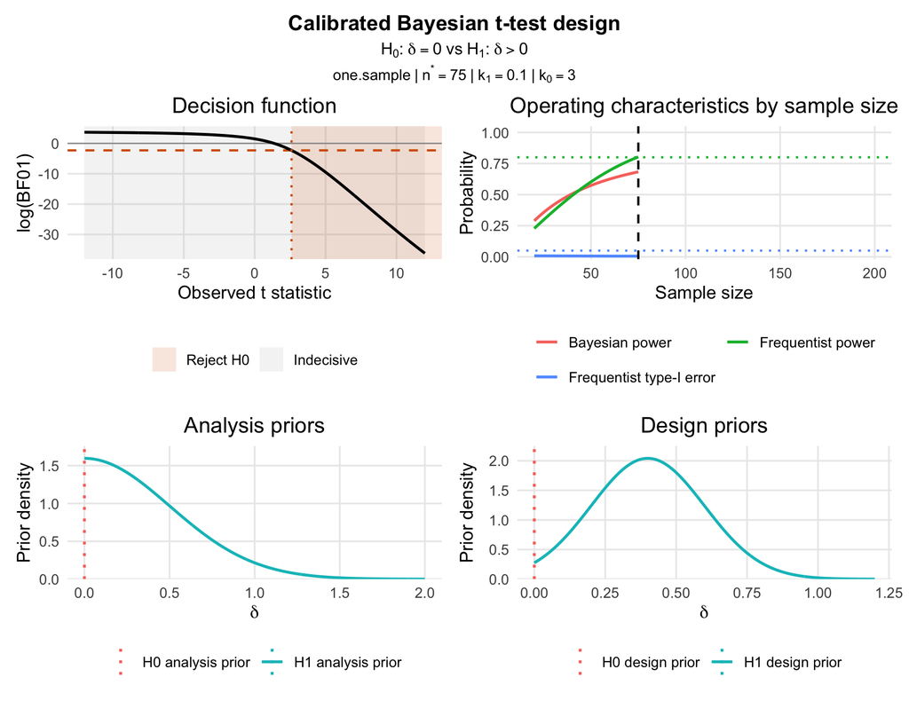

Figure 2: Output of the plot function for a one-sample Bayesian t-test design based on frequentist calibration.

```r
plot(pulmonary_directional_freq)
```

Figure 2 shows that the shape of the decision function now reflects the one-sided test. For increasingly large t-statistic, the Bayes factor will reject $H_0$. Note that the top right panel in Figure 2 shows Bayesian power (as the design prior under $H_1$ is specified in the common parameters above), but only frequentist power and type-I-error are used for calibrating the required sample size.

### 3.2 Bayesian calibration

This design controls the $H_0$-design-prior average probability of incorrectly obtaining compelling evidence for benefit and requires 80% average Bayesian power under the $H_1$ design prior.

```r
pulmonary_directional_bayes <- do.call(
  calibrate_bf_ttest,
  c(
    directional_common_args,
    list(
      bayes_t1e = 0.05,
      bayes_power = 0.80
    )
  )
)

print(pulmonary_directional_bayes)
```

```
Calibrated Bayesian t-test design
---------------------------------
Design: one.sample
Hypothesis: greater.pointnull
n*: 134 (df = 133 )
Thresholds: k1 = 0.1 , k0 = 3
Analysis prior under H0:
Point prior: delta = 0
Analysis prior under H1:
Prior: TN(0, 0.5^2; [0, Inf))
  family:   normal
  location: 0
  scale:    0.5
  support:  [0, Inf]
Evidence for H1 region(s) on t-scale:
        lower upper
[1,] 2.666093   Inf
Evidence for H0 region(s) on t-scale:
none

Constraints:
  constraint     type
   bayes_t1e Bayesian
 bayes_power Bayesian
                estimand   estimate target
 P_design,H0(BF01 <= k1) 0.00431281   0.05
 P_design,H1(BF01 <= k1) 0.80025788   0.80
 direction        slack satisfied
        <= 0.0456871901      TRUE
        >= 0.0002578833      TRUE
```

Since the Bayesian type-I-error under $H_0:\delta = 0$ is computed under a point-prior, the Bayesian type-I-error rate is identical to the frequentist one. This is the reason that the plot shows frequentist type-I-error (which usually is more conservative), even though the calibration uses Bayesian type-I-error (and power).

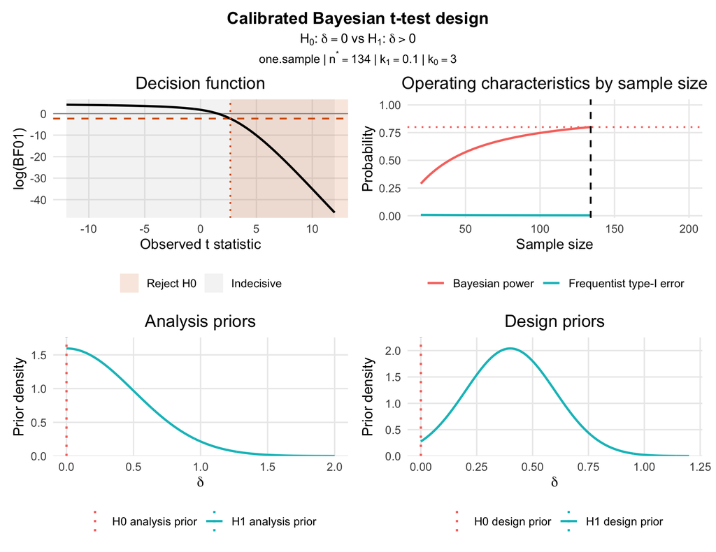

Figure 3: Output of the plot function for a one-sample Bayesian t-test design based on Bayesian calibration.

```r
plot(pulmonary_directional_bayes)
```

### 3.3 Hybrid calibration

This hybrid calibration uses a frequentist type-I error requirement at $\delta=0$ and a Bayesian power requirement averaged over the $H_1$ design prior.

```r
pulmonary_directional_bayes_power_freq_t1e <- do.call(
  calibrate_bf_ttest,
  c(
    directional_common_args,
    list(
      freq_t1e = 0.05,
      bayes_power = 0.80
    )
  )
)

print(pulmonary_directional_bayes_power_freq_t1e)
```

```
Calibrated Bayesian t-test design
---------------------------------
Design: one.sample
Hypothesis: greater.pointnull
n*: 134 (df = 133 )
Thresholds: k1 = 0.1 , k0 = 3
Analysis prior under H0:
Point prior: delta = 0
Analysis prior under H1:
Prior: TN(0, 0.5^2; [0, Inf))
  family:   normal
  location: 0
  scale:    0.5
  support:  [0, Inf]
Evidence for H1 region(s) on t-scale:
        lower upper
[1,] 2.666093   Inf
Evidence for H0 region(s) on t-scale:
none

Constraints:
  constraint        type
    freq_t1e frequentist
 bayes_power    Bayesian
                estimand   estimate target
   P_delta=0(BF01 <= k1) 0.00431281   0.05
 P_design,H1(BF01 <= k1) 0.80025788   0.80
 direction        slack satisfied
        <= 0.0456871901      TRUE
        >= 0.0002578833      TRUE
```

### 3.4 Full calibration without PCE

This version activates frequentist and Bayesian type-I error requirements, as well as frequentist and Bayesian power requirements. It does not impose a probability-of-compelling-evidence (PCE) requirement for $H_0$.

```r
pulmonary_directional_full_no_pce <- do.call(
  calibrate_bf_ttest,
  c(
    directional_common_args,
    list(
      freq_t1e = 0.05,
      bayes_t1e = 0.05,
      freq_power = list(
        main = list(effect = 0.40, target = 0.80)
      ),
      bayes_power = 0.80
    )
  )
)

print(pulmonary_directional_full_no_pce)
```

```
Calibrated Bayesian t-test design
---------------------------------
Design: one.sample
Hypothesis: greater.pointnull
n*: 134 (df = 133 )
Thresholds: k1 = 0.1 , k0 = 3
Analysis prior under H0:
Point prior: delta = 0
Analysis prior under H1:
Prior: TN(0, 0.5^2; [0, Inf))
  family:   normal
  location: 0
  scale:    0.5
  support:  [0, Inf]
Evidence for H1 region(s) on t-scale:
        lower upper
[1,] 2.666093   Inf
Evidence for H0 region(s) on t-scale:
none

Constraints:
      constraint        type
        freq_t1e frequentist
       bayes_t1e    Bayesian
     bayes_power    Bayesian
 freq_power_main frequentist
                estimand   estimate target
   P_delta=0(BF01 <= k1) 0.00431281   0.05
 P_design,H0(BF01 <= k1) 0.00431281   0.05
 P_design,H1(BF01 <= k1) 0.80025788   0.80
 P_delta=0.4(BF01 <= k1) 0.97401497   0.80
 direction        slack satisfied
        <= 0.0456871901      TRUE
        <= 0.0456871901      TRUE
        >= 0.0002578833      TRUE
        >= 0.1740149710      TRUE
```

We see that all calibrations except the frequentit one require $n^{\star}=134$ patients. Frequentist calibration under the much more optimistic point prior at $\delta = 0.4$ requires solely $n^{\star}=75$ patients.

The point-null versus greater directional test shows that the directional Bayes factor is asymmetric in the observed $t$ statistic, compare the top left panel in Figure 2. The region providing evidence for $H_1$ should therefore occur in the positive tail only. The implementation determines decision regions by finding the relevant Bayes-factor roots and classifying the resulting intervals rather than imposing a symmetric decision geometry.

## 4 Example 3: Directional composite-null design

This example is inspired by an 8-week open-label, multicentre study of inhaled tobramycin in people with cystic fibrosis and *Pseudomonas aeruginosa* infection, compare Sutharsan et al. (2020). The published study assessed pulmonary outcomes including forced expiratory volume in 1 second (FEV1) and lung-clearance index (LCI).

We consider a hypothetical future single-arm proof-of-concept study. Let the endpoint be improvement in LCI from baseline to Week 8, coded as baseline minus follow-up LCI. Thus, a positive value denotes clinical improvement.

The scientific question is whether the intervention provides evidence of benefit rather than merely evidence against an exact zero mean change:

$$H_0:\delta\leq0
\quad\text{versus}\quad
H_1:\delta>0.$$

The null-side hypothesis includes both no improvement and deterioration. This is appropriate when a benefit claim should be made only when the study yields compelling evidence for an improvement.

```r
composite_lci_continuous <- calibrate_bf_ttest(
  design = "one.sample",
  hypothesis = "greater.composite",
  n_min = 20,
  n_max = 120,
  k1 = 1 / 20,
  k0 = 3,

  analysis_prior_h0 = make_analysis_prior_less_equal(sd = 0.5),
  analysis_prior_h1 = make_analysis_prior_greater(sd = 0.5),

  freq_t1e = 0.05,
  freq_power = list(main = list(effect = 0.40, target = 0.80)),
  bayes_t1e = 0.05,
  bayes_power = 0.80,
  pce_h0 = 0.60,

  design_prior_h0 = list(
    type = "truncnormal",
    mean = -0.10,
    sd = 0.25,
    lower = -Inf,
    upper = 0
  ),
  design_prior_h1 = list(
    type = "truncnormal",
    mean = 0.40,
    sd = 0.20,
    lower = 0,
    upper = Inf
  ),

  control = fast_control
)

composite_lci_continuous
```

```
Calibrated Bayesian t-test design
---------------------------------
Design: one.sample
Hypothesis: greater.composite
n*: 65 (df = 64 )
Thresholds: k1 = 0.05 , k0 = 3
Analysis prior under H0:
Prior: TN(0, 0.5^2; (-Inf, 0])
  family:   normal
  location: 0
  scale:    0.5
  support:  [-Inf, 0]
Analysis prior under H1:
Prior: TN(0, 0.5^2; [0, Inf))
  family:   normal
  location: 0
  scale:    0.5
  support:  [0, Inf]
Evidence for H1 region(s) on t-scale:
        lower upper
[1,] 1.733227   Inf
Evidence for H0 region(s) on t-scale:
     lower      upper
[1,]  -Inf -0.6935961

Constraints:
      constraint        type                estimand    estimate
        freq_t1e frequentist   P_delta=0(BF01 <= k1) 0.043935585
       bayes_t1e    Bayesian P_design,H0(BF01 <= k1) 0.005294749
     bayes_power    Bayesian P_design,H1(BF01 <= k1) 0.802264572
          pce_h0    Bayesian P_design,H0(BF01 >= k0) 0.758721651
 freq_power_main frequentist P_delta=0.4(BF01 <= k1) 0.930717800
 target direction       slack satisfied
   0.05        <= 0.006064415      TRUE
   0.05        <= 0.044705251      TRUE
   0.80        >= 0.002264572      TRUE
   0.60        >= 0.158721651      TRUE
   0.80        >= 0.130717800      TRUE
```

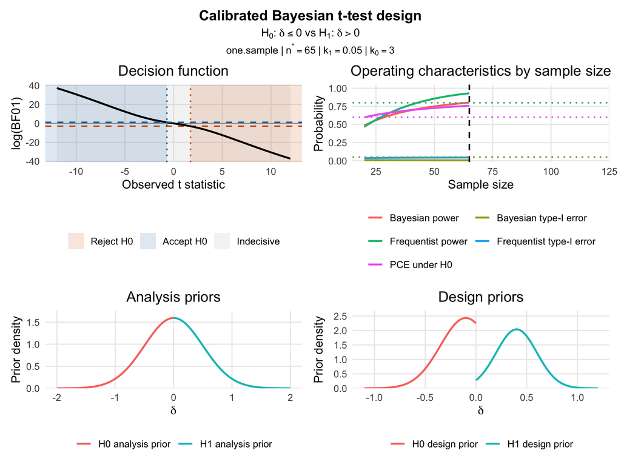

```r
plot(composite_lci_continuous)
```

As a sidenote, single-arm change-from-baseline evidence is vulnerable to within-person variability, natural history, regression to the mean, and measurement error; it does not itself establish a causal treatment effect, in contrast to two-arm change-from-baseline evidence. However, the composite-null formulation clarifies the evidential decision rule. What it cannot achieve, however, it to remove the limitations of a non-comparative design. External controls, randomization, or other design features may be necessary for a confirmatory efficacy claim. We study this example nevertheless, because a directional composite-null design is widely used in clinical trials.

## 5 Comparison with a conventional frequentist design

The conventional comparator is a one-sided one-sample t-test,

$$H_0: \delta \leq 0
\qquad \text{versus} \qquad
H_1: \delta > 0,$$

designed for a type-I error rate of 0.05 and 80% power at the fixed alternative $\delta = 0.40$. We also consider a Bayes-factor design that retains the frequentist type-I-error and power requirements but does not require compelling evidence for the H0 region. This separates the sample-size implication of requiring strong evidence for H1 from the additional requirement to obtain compelling H0 evidence.

```r
## Conventional frequentist one-sided one-sample t-test
freq_design <- power.t.test(
  delta = 0.40,
  sd = 1,
  sig.level = 0.05,
  power = 0.80,
  type = "one.sample",
  alternative = "one.sided"
)

freq_n <- ceiling(freq_design$n)
```

```r
## Bayes-factor design: H1 evidence only, no PCE requirement.
composite_lci_no_pce <- calibrate_bf_ttest(
  design = "one.sample",
  hypothesis = "greater.composite",
  n_min = 20,
  n_max = 120,
  k1 = 1 / 20,
  k0 = 3,

  analysis_prior_h0 = make_analysis_prior_less_equal(sd = 0.5),
  analysis_prior_h1 = make_analysis_prior_greater(sd = 0.5),

  freq_t1e = 0.05,
  freq_power = list(main = list(effect = 0.40, target = 0.80)),

  design_prior_h0 = list(
    type = "truncnormal",
    mean = -0.10,
    sd = 0.25,
    lower = -Inf,
    upper = 0
  ),
  design_prior_h1 = list(
    type = "truncnormal",
    mean = 0.40,
    sd = 0.20,
    lower = 0,
    upper = Inf
  ),

  control = fast_control
)
```

```r
sample_size_comparison <- data.frame(
  design = c(
    "Frequentist one-sample t-test",
    "Bayes-factor design: H1 evidence only",
    "Bayes-factor design: H1 and H0 evidence"
  ),
  type_I_error_control = c(
    "One-sided alpha = 0.05",
    "P(delta = 0; BF01 <= 1/20) <= 0.05",
    "P(delta = 0; BF01 <= 1/20) <= 0.05"
  ),
  power_requirement = c(
    "Power(delta = 0.40) >= 0.80",
    "P(delta = 0.40; BF01 <= 1/20) >= 0.80",
    "P(delta = 0.40; BF01 <= 1/20) >= 0.80"
  ),
  H0_evidence_requirement = c(
    "None",
    "None",
    "P_design,H0(BF01 >= 3) >= 0.60"
  ),
  sample_size = c(
    freq_n,
    composite_lci_no_pce$n,
    composite_lci_continuous$n
  ),
  stringsAsFactors = FALSE
)

knitr::kable(
  sample_size_comparison,
  col.names = c(
    "Design",
    "Type-I-error control",
    "Power requirement",
    "H0-evidence requirement",
    "Required n"
  ),
  caption = "Sample-size comparison under a one-sided standardized effect of 0.40."
)
```

Sample-size comparison under a one-sided standardized effect of 0.40.

| Design | Type-I-error control | Power requirement | H0-evidence requirement | Required n |
| --- | --- | --- | --- | --- |
| Frequentist one-sample t-test | One-sided alpha = 0.05 | Power(delta = 0.40) >= 0.80 | None | 41 |
| Bayes-factor design: H1 evidence only | P(delta = 0; BF01 <= 1/20) <= 0.05 | P(delta = 0.40; BF01 <= 1/20) >= 0.80 | None | 43 |
| Bayes-factor design: H1 and H0 evidence | P(delta = 0; BF01 <= 1/20) <= 0.05 | P(delta = 0.40; BF01 <= 1/20) >= 0.80 | P_design,H0(BF01 >= 3) >= 0.60 | 65 |

The conventional frequentist calculation requires 41 patients. The BF design without a probability-of-compelling-evidence (PCE) requirement requires 43 patients. Its slightly larger sample size reflects the use of the more stringent evidential criterion $BF_{01} \leq 1/20$, rather than a conventional one-sided significance threshold.

Adding the requirement that the design yield compelling $H_0$ evidence ($BF_{01} \geq 3$) with probability at least 0.60 under the $H_0$ design prior increases the required sample size to 65. Thus, the PCE requirement adds 22 patients beyond the $H_1$-evidence-only BF design, and the complete calibrated design adds 24 patients beyond the conventional frequentist design.

## 6 Example 4: Paired one-sample design

This example is inspired by the Healthy BP study, which compared a dietitian-led telehealth lifestyle intervention with a self-directed intervention. Its primary endpoint was change in 24-hour ambulatory systolic blood pressure from baseline to 12 weeks, see Taher et al. (2021).

Here, we consider a hypothetical future single-group implementation study with measurements at the same two time points. This is a prospective design illustration, not a reproduction of the original randomized trial or its between-group analysis. All effect sizes, prior distributions, evidence thresholds, and calibration targets below are illustrative planning assumptions rather than quantities attributed to that trial.

### 6.1 Paired outcome and hypothesis

Define the participant-level outcome as

$$D_i
=
X_{i,\mathrm{baseline}}
-
X_{i,\mathrm{12\ weeks}},$$

so that a positive difference represents a beneficial reduction in systolic blood pressure. Let

$$\mu_D = \mathbb{E}(D_i),
\qquad
\sigma_D = \operatorname{SD}(D_i),
\qquad
\delta = \frac{\mu_D}{\sigma_D}.$$

A clinically relevant reduction of 5 mmHg and an assumed planning standard deviation of paired differences of 12.5 mmHg imply

$$\delta_A = \frac{5}{12.5} = 0.40.$$

The standard deviation in this calculation is the standard deviation of the within-participant differences, not the standard deviation of baseline or follow-up blood pressure considered separately.

We use the directional composite-null hypotheses

$$H_0:\delta\leq0
\qquad\text{versus}\qquad
H_1:\delta>0.$$

Thus, the null-side hypothesis includes both no mean reduction and a mean increase in blood pressure.

For a paired design, $n$ is the number of participants with evaluable baseline and follow-up measurements. The test statistic is

$$T = \frac{\sqrt{n}\,\bar D}{S_D},
\qquad
T\mid\delta \sim t_{n-1}(\sqrt{n}\delta).$$

The statistical engine is therefore the same as for a one-sample test of the participant-level differences.

### 6.2 Priors, evidence thresholds, and calibration targets

We use normal analysis priors with scale 0.5, truncated and normalized on the respective hypothesis regions:

$$\delta\mid H_0
\sim N(0,0.5^2)\big|_{(-\infty,0]},
\qquad
\delta\mid H_1
\sim N(0,0.5^2)\big|_{(0,\infty)}.$$

These analysis priors define the Bayes factor. For planning, we use separate design priors:

$$\pi_{d,0}
=
N(-0.10,0.25^2)\big|_{(-\infty,0]},
\qquad
\pi_{d,1}
=
N(0.40,0.20^2)\big|_{(0,\infty)}.$$

The evidence thresholds are fixed in advance:

- $BF_{01}\leq1/20$: compelling evidence for a beneficial reduction;
- $BF_{01}\geq3$: compelling evidence for the null-side hypothesis;
- otherwise: an inconclusive result.

We jointly require:

- pointwise frequentist type-I error at $\delta=0$ at most 0.05;
- frequentist power at $\delta=0.40$ at least 0.80;
- Bayesian type-I error under the null-side design prior at most 0.05;
- Bayesian power under the beneficial-effect design prior at least 0.80;
- probability of compelling null-side evidence under the null-side design prior at least 0.60.

```r
paired_bp <- calibrate_bf_ttest(
  design = "paired",
  hypothesis = "greater.composite",

  # Number of evaluable participant pairs.
  n_min = 20,
  n_max = 120,

  # Prespecified, fixed evidence thresholds.
  k1 = 1 / 20,
  k0 = 3,

  # Default composite-null analysis priors:
  # N(0, 0.5^2), truncated to the respective half-lines.
  analysis_prior_sd = 0.5,

  freq_t1e = 0.05,
  freq_power = list(
    main = list(effect = 0.40, target = 0.80)
  ),
  bayes_t1e = 0.05,
  bayes_power = 0.80,
  pce_h0 = 0.60,

  design_prior_h0 = list(
    type = "truncnormal",
    mean = -0.10,
    sd = 0.25,
    lower = -Inf,
    upper = 0
  ),
  design_prior_h1 = list(
    type = "truncnormal",
    mean = 0.40,
    sd = 0.20,
    lower = 0,
    upper = Inf
  ),

  control = control_full_fast
)

print(paired_bp)
```

```
Calibrated Bayesian t-test design
---------------------------------
Design: paired
Hypothesis: greater.composite
n*: 65 (df = 64 )
Thresholds: k1 = 0.05 , k0 = 3
Analysis prior under H0:
Prior: TN(0, 0.5^2; (-Inf, 0])
  family:   normal
  location: 0
  scale:    0.5
  support:  [-Inf, 0]
Analysis prior under H1:
Prior: TN(0, 0.5^2; [0, Inf))
  family:   normal
  location: 0
  scale:    0.5
  support:  [0, Inf]
Evidence for H1 region(s) on t-scale:
        lower upper
[1,] 1.733227   Inf
Evidence for H0 region(s) on t-scale:
     lower      upper
[1,]  -Inf -0.6935961

Constraints:
      constraint        type                estimand    estimate
        freq_t1e frequentist   P_delta=0(BF01 <= k1) 0.043935585
       bayes_t1e    Bayesian P_design,H0(BF01 <= k1) 0.005294749
     bayes_power    Bayesian P_design,H1(BF01 <= k1) 0.802264572
          pce_h0    Bayesian P_design,H0(BF01 >= k0) 0.758721651
 freq_power_main frequentist P_delta=0.4(BF01 <= k1) 0.930717800
 target direction       slack satisfied
   0.05        <= 0.006064415      TRUE
   0.05        <= 0.044705251      TRUE
   0.80        >= 0.002264572      TRUE
   0.60        >= 0.158721651      TRUE
   0.80        >= 0.130717800      TRUE
```

### 6.3 Calibrated design

The selected sample size is $n^\star = 65$ evaluable participant pairs, with $64$ degrees of freedom. Thus, the design requires at least $65$ participants contributing both measurements, not $2\cdot 65=130$ independently sampled participants.

### 6.4 Interpretation and relation to the one-sample example

This example uses the same standardized-effect priors, fixed evidence thresholds, and calibration requirements as the composite-null one-sample example. Consequently, with identical numerical controls, the paired and one-sample calculations represent the same mathematical calibration problem. What changes is the interpretation of the outcome and sample size: here the observations are participant-level differences and $n$ counts evaluable pairs.

Repeated baseline and follow-up measurements are not independent observations. Their dependence is incorporated through the standard deviation of the paired differences. If planning information is available only for the marginal standard deviations and within-participant correlation, then

$$\sigma_D^2
=
\sigma_{\mathrm{baseline}}^2
+
\sigma_{\mathrm{follow\text{-}up}}^2
-
2\rho\,
\sigma_{\mathrm{baseline}}
\sigma_{\mathrm{follow\text{-}up}}.$$

The assumed value $\sigma_D=12.5$ mmHg should therefore be justified using relevant paired data or examined in sensitivity analyses.

Finally, the calibrated sample size refers to evaluable pairs. Recruitment inflation for missing follow-up measurements should be considered separately. Neither such inflation nor the paired analysis itself resolves bias arising from informative missingness or the causal limitations of a single-group study.

## 7 Interpretation

`calibrate_bf_ttest()` returns the smallest sample size in the requested range that satisfies the activated constraints. The returned object includes the Bayes-factor evidence regions, attained operating characteristics, constraint table, and numerical controls used for the calculation.

The examples are illustrations of a design procedure. They do not imply that a Bayesian design automatically requires fewer participants than a conventional design; any difference follows from the chosen evidence thresholds and jointly calibrated operating-characteristic requirements.

## References

Sutharsan, Sivagurunathan, Susanne Naehrig, Uwe Mellies, Christian Sieder, and Jörg Ziegler. 2020. “An 8 Week Open-Label Interventional Multicenter Study to Explore the Lung Clearance Index as Endpoint for Clinical Trials in Cystic Fibrosis Patients $\geq$8 Years of Age, Chronically Infected with Pseudomonas Aeruginosa.” *BMC Pulm Med* 20: 167. https://doi.org/10.1186/s12890-020-01201-y.

Taher, Mohamed, Christina Yule, Heather Bonaparte, Sara Kwiecien, Charlotte Collins, Allison Naylor, S P Juraschek, Lisa Bailey-Davis, and Alex R Chang. 2021. “Telehealth Versus Self-Directed Lifestyle Intervention to Promote Healthy Blood Pressure: A Protocol for a Randomised Controlled Trial.” *BMJ Open* 11 (3): e044292. https://doi.org/10.1136/bmjopen-2020-044292.

Vijaykumar, Kadambari, George M. Solomon, Jennifer Guimbellot, Edward P. Acosta, Pradeep G. Bhambhavni, Sharon White, Harrison Kim, et al. 2025. “Ivacaftor for Chronic Obstructive Pulmonary Disease: Results from a Phase 2, Randomized Controlled Trial.” *Am J Respir Crit Care Med* 211 (5): 823–31. https://doi.org/10.1164/rccm.202407-1302OC.